# Практика · PCA — метод головних компонент

> Лекція: lecture.html · Тест: quiz.html · Домашнє: homework.html

Той самий приклад, що й у лекції: дошка оголошень про вживані телефони з теми 08. Сім числових ознак, які неможливо намалювати разом.

Що ми зробимо:

1. зберемо ту саму таблицю й дістанемо з неї **сім числових ознак**;
2. знайдемо пару колонок, які майже дублюють одна одну;
3. порахуємо PCA **вручну на NumPy** — центрування, коваріаційна матриця, `np.linalg.eigh`;
4. звіримо результат із `sklearn.decomposition.PCA` — числа мають зійтися;
5. повторимо ручний приклад із шести точок із лекції й перевіримо власні числа 28 і 4;
6. подивимось на пояснену дисперсію: скільки компонент треба для 90 %;
7. намалюємо дошку у двох компонентах і пофарбуємо за `шахрайське`, якого PCA не бачив;
8. побачимо, у що перетворюється перша компонента **без** `StandardScaler`;
9. поміряємо витік, який дає PCA, порахований до поділу даних.

Зерно генератора зафіксовано (`np.random.default_rng(42)`), тож числа збігатимуться з лекцією до цифри.

```python
import numpy as np
import pandas as pd
import matplotlib.pyplot as plt

from sklearn.preprocessing import StandardScaler
from sklearn.decomposition import PCA
from sklearn.model_selection import train_test_split

# зерно фіксує всю випадковість: у тебе вийдуть точно ті самі числа, що в лекції
rng = np.random.default_rng(42)

pd.set_option("display.width", 130)
pd.set_option("display.max_columns", 14)
np.set_printoptions(suppress=True, linewidth=130)

print("numpy", np.__version__, "· pandas", pd.__version__)
```

```
numpy 2.5.1 · pandas 2.3.3
```

## 1 · Збираємо ту саму дошку

Цей блок — код із практики теми 08 без змін. Ми його не пояснюємо повторно, а просто відтворюємо таблицю, щоб числа збіглися.

```python
кількість = 1200

моделі = ["Alfa A5", "Alfa A7", "Beta 12", "Beta 12 Pro", "Gamma X", "Gamma X Ultra"]
ціна_нового = {"Alfa A5": 5200, "Alfa A7": 7400, "Beta 12": 12000,
               "Beta 12 Pro": 17500, "Gamma X": 24000, "Gamma X Ultra": 34000}
частки_моделей = [0.24, 0.22, 0.18, 0.16, 0.12, 0.08]

модель = rng.choice(моделі, size=кількість, p=частки_моделей)
рік = rng.integers(2017, 2025, size=кількість)
стан = rng.choice(["нове", "дуже добре", "добре", "задовільне"],
                  size=кількість, p=[0.08, 0.32, 0.42, 0.18])
памʼять = rng.choice([64, 128, 256, 512], size=кількість, p=[0.30, 0.38, 0.24, 0.08])
вік_акаунта = np.round(rng.exponential(420, size=кількість) + 3).astype(int)

базова = np.array([ціна_нового[m] for m in модель])
знос = 0.82 ** (2024 - рік)
коефіцієнт_стану = np.array(
    [{"нове": 1.0, "дуже добре": 0.88, "добре": 0.75, "задовільне": 0.58}[s] for s in стан])
коефіцієнт_памʼяті = np.array(
    [{64: 0.85, 128: 1.0, 256: 1.15, 512: 1.32}[m] for m in памʼять])

типова_ціна_за_паспортом = базова * знос * коефіцієнт_стану * коефіцієнт_памʼяті
ціна = типова_ціна_за_паспортом * rng.lognormal(0, 0.13, size=кількість)

print("перші пʼять цін:", ціна[:5].round(0))
```

```
перші пʼять цін: [ 3085.  2810. 10822.  8346.  1852.]
```

```python
# шахрай тим імовірніший, чим молодший акаунт; ціну він або занижує (приманка),
# або завищує під велику передоплату
шанс_шахрайства = 0.10 + 0.30 * np.exp(-вік_акаунта / 120)
шахрайське = rng.random(кількість) < шанс_шахрайства

ставить_дешево = rng.random(кількість) < 0.74
дешева_приманка = шахрайське & ставить_дешево
дорога_приманка = шахрайське & ~ставить_дешево

ціна[дешева_приманка] = (типова_ціна_за_паспортом[дешева_приманка]
                         * rng.uniform(0.20, 0.45, дешева_приманка.sum()))
ціна[дорога_приманка] = (типова_ціна_за_паспортом[дорога_приманка]
                         * rng.uniform(2.6, 3.8, дорога_приманка.sum()))
ціна = np.round(ціна, -1)

скарг = np.where(шахрайське, 1 + rng.poisson(3.0, кількість), rng.poisson(0.03, кількість))

дошка = pd.DataFrame({
    "модель": модель, "рік": рік, "стан": стан, "памʼять_гб": памʼять,
    "вік_акаунта": вік_акаунта, "скарг": скарг, "ціна": ціна,
    "шахрайське": шахрайське.astype(int),
})
print("шахрайських оголошень:", int(дошка["шахрайське"].sum()), "з", кількість)
```

```
шахрайських оголошень: 196 з 1200
```

```python
# ті самі шість неприємностей із теми 08 — колекційні, одруки, памʼять текстом,
# пропуски в ціні та стані, дублікати
колекційні = дошка.index[дошка["модель"] == "Gamma X"][:4]
дошка.loc[колекційні, ["рік", "стан", "памʼять_гб"]] = [2017, "нове", 512]
дошка.loc[колекційні, "ціна"] = [82000.0, 88000.0, 91000.0, 95000.0]
дошка.loc[колекційні, ["шахрайське", "скарг"]] = 0

одруки = дошка.index[(дошка["ціна"] > 7000) & (дошка["ціна"] < 9600)
                     & (дошка["шахрайське"] == 0)][:2]
дошка.loc[одруки, "ціна"] = дошка.loc[одруки, "ціна"] * 10

памʼять_текстом = дошка["памʼять_гб"].astype(str)
із_одиницями = rng.random(len(дошка)) < 0.18
памʼять_текстом[із_одиницями] = памʼять_текстом[із_одиницями] + " ГБ"
дошка["памʼять_гб"] = памʼять_текстом

ймовірність_пропуску = np.where(дошка["шахрайське"] == 1, 0.25, 0.03)
дошка.loc[rng.random(len(дошка)) < ймовірність_пропуску, "ціна"] = np.nan
дошка.loc[rng.random(len(дошка)) < 0.04, "стан"] = np.nan

повтори = rng.choice(дошка.index, size=12, replace=False)
дошка = pd.concat([дошка, дошка.loc[повтори]], ignore_index=True)

assert дошка.shape == (1212, 8), "форма розійшлась із темою 22"
print("таблиця як у темі 08:", дошка.shape)
```

```
таблиця як у темі 08: (1212, 8)
```

## 2 · Сім числових ознак

PCA працює тільки з числами й тільки без пропусків. Тому робимо чотири речі:

- прибираємо суфікс «ГБ» і повні дублікати рядків — це та сама безумовна чистка, що й у практиці теми 08;
- перетворюємо стан на бал від 1 до 4 (порядкова шкала, тема 09);
- додаємо дві оцінки «скільки цей телефон приблизно коштує»: медіану реальних цін для пари «модель + рік» і оцінку з каталогу (ціна нового мінус 18 % за кожен рік);
- залишаємо тільки оголошення з відомою ціною — їх 1 100 із 1 200.

Колонку `скарг` не беремо: це витік, знайдений ще в темі 08, — скарги зʼявляються вже після публікації.

```python
дошка["памʼять_гб"] = pd.to_numeric(дошка["памʼять_гб"].str.replace(" ГБ", "", regex=False))
дошка = дошка.drop_duplicates().reset_index(drop=True)

# стан — порядкова шкала: чим більше, тим кращий апарат
бали_стану = {"задовільне": 1, "добре": 2, "дуже добре": 3, "нове": 4}
# пропуск у стані заповнюємо найчастішим балом, щоб не викидати рядок цілком
дошка["стан_бал"] = дошка["стан"].map(бали_стану).fillna(2).astype(int)

# без ціни неможливо порахувати жодну з цінових ознак, тож ці рядки відкладаємо
оголошення = дошка.dropna(subset=["ціна"]).reset_index(drop=True)

# перша оцінка вартості: медіана реальних цін усередині групи «модель + рік»
оголошення["типова_ціна"] = (оголошення.groupby(["модель", "рік"])["ціна"]
                             .transform("median"))
# друга оцінка вартості: ціна нового апарата мінус 18 % зношення за кожен рік
оголошення["оцінка_каталогу"] = (оголошення["модель"].map(ціна_нового)
                                 * 0.82 ** (2024 - оголошення["рік"])).round(0)

назви_ознак = ["ціна", "типова_ціна", "оцінка_каталогу", "рік",
               "памʼять_гб", "стан_бал", "вік_акаунта"]
X = оголошення[назви_ознак].to_numpy(float)
таргет = оголошення["шахрайське"].to_numpy()

print("матриця ознак:", X.shape)
print("шахрайських оголошень:", int(таргет.sum()),
      f"({таргет.mean() * 100:.1f} %)")
print()
print(оголошення[назви_ознак].agg(["mean", "std", "min", "max"]).T.round(1))
```

```
матриця ознак: (1100, 7)
шахрайських оголошень: 139 (12.6 %)
```

```
                   mean     std     min      max
ціна             6498.2  8689.0   130.0  95000.0
типова_ціна      5771.6  5077.0  1020.0  31915.0
оцінка_каталогу  7394.5  6149.9  1296.0  34000.0
рік              2020.5     2.3  2017.0   2024.0
памʼять_гб        169.5   123.8    64.0    512.0
стан_бал            2.3     0.9     1.0      4.0
вік_акаунта       404.7   406.7     4.0   3519.0
```

## 3 · Дві колонки, які кажуть те саме

`типова_ціна` й `оцінка_каталогу` відповідають на одне питання різними способами. Подивимось, наскільки вони насправді різні.

```python
матриця_кореляцій = оголошення[назви_ознак].corr()

# шукаємо найсильнішу пару, щоб не вибирати її на око
найсильніша_пара, найсильніша_кореляція = None, 0.0
for i in range(len(назви_ознак)):
    for j in range(i + 1, len(назви_ознак)):
        значення = матриця_кореляцій.iloc[i, j]
        if abs(значення) > abs(найсильніша_кореляція):
            найсильніша_пара = (назви_ознак[i], назви_ознак[j])
            найсильніша_кореляція = значення

print(матриця_кореляцій.round(3))
print()
print("найсильніша пара:", найсильніша_пара, "· кореляція", round(найсильніша_кореляція, 3))
```

```
                  ціна  типова_ціна  оцінка_каталогу    рік  памʼять_гб  стан_бал  вік_акаунта
ціна             1.000        0.596            0.586  0.247       0.210     0.155       -0.030
типова_ціна      0.596        1.000            0.989  0.501       0.020    -0.008       -0.030
оцінка_каталогу  0.586        0.989            1.000  0.527       0.015    -0.028       -0.031
рік              0.247        0.501            0.527  1.000      -0.030    -0.027       -0.032
памʼять_гб       0.210        0.020            0.015 -0.030       1.000    -0.027       -0.025
стан_бал         0.155       -0.008           -0.028 -0.027      -0.027     1.000        0.063
вік_акаунта     -0.030       -0.030           -0.031 -0.032      -0.025     0.063        1.000

найсильніша пара: ('типова_ціна', 'оцінка_каталогу') · кореляція 0.989
```

Кореляція 0.989 означає, що друга колонка майже не додає нового виміру. PCA має це помітити сам — перевіримо наприкінці розділу 5.

## 4 · PCA руками на NumPy

`eigh` (а не `eig`) — тому що коваріаційна матриця симетрична: для таких матриць є швидший і точніший алгоритм, і він завжди повертає дійсні числа. Повертає він їх за **зростанням**, тому список доведеться перевернути.

```python
масштабувальник = StandardScaler().fit(X)
Z = масштабувальник.transform(X)          # центровано й поділено на стандартне відхилення

# rowvar=False означає «колонки — це ознаки, рядки — обʼєкти»
коваріація = np.cov(Z, rowvar=False)
print("коваріаційна матриця 7×7 (вона ж матриця кореляцій, бо дані стандартизовані):")
print(np.round(коваріація, 3))
```

```
коваріаційна матриця 7×7 (вона ж матриця кореляцій, бо дані стандартизовані):
[[ 1.001  0.596  0.586  0.248  0.21   0.155 -0.03 ]
 [ 0.596  1.001  0.99   0.501  0.02  -0.008 -0.03 ]
 [ 0.586  0.99   1.001  0.528  0.015 -0.028 -0.031]
 [ 0.248  0.501  0.528  1.001 -0.03  -0.027 -0.032]
 [ 0.21   0.02   0.015 -0.03   1.001 -0.027 -0.025]
 [ 0.155 -0.008 -0.028 -0.027 -0.027  1.001  0.063]
 [-0.03  -0.03  -0.031 -0.032 -0.025  0.063  1.001]]
```

```python
власні_числа, власні_вектори = np.linalg.eigh(коваріація)

# eigh віддає власні числа за зростанням — нам потрібен зворотний порядок
порядок = np.argsort(власні_числа)[::-1]
власні_числа = власні_числа[порядок]
# власні вектори стоять у СТОВПЦЯХ, тому переставляємо стовпці, а потім транспонуємо:
# так кожен рядок стане однією компонентою — як у sklearn
компоненти_вручну = власні_вектори[:, порядок].T

частка = власні_числа / власні_числа.sum()

print("власні числа       :", власні_числа.round(4))
print("частка розкиду, %  :", (частка * 100).round(2))
print("накопичено, %      :", (np.cumsum(частка) * 100).round(2))
```

```
власні числа       : [2.7963 1.1127 1.0755 0.9463 0.6691 0.3962 0.0103]
частка розкиду, %  : [39.91 15.88 15.35 13.51  9.55  5.66  0.15]
накопичено, %      : [ 39.91  55.79  71.14  84.65  94.2   99.85 100.  ]
```

## 5 · Звіряємо з бібліотекою

Тепер те саме через `sklearn.decomposition.PCA`. Числа мають збігтися — з однією обмовкою про знак.

**Про знак.** Якщо вектор `u` задає напрямок найбільшого розкиду, то `−u` задає той самий напрямок, просто дивиться в інший бік. Обидва однаково правильні, і різні бібліотеки (і навіть різні версії однієї) можуть повернути різні. Тому порівнювати компоненти треба **за модулем**, а картинку в компонентах не дивує, коли вона виявляється дзеркальною.

```python
pca = PCA().fit(Z)

# власні числа — це і є explained_variance_ бібліотеки
assert np.allclose(власні_числа, pca.explained_variance_), "власні числа розійшлись!"
# компоненти збігаються з точністю до знака, тому порівнюємо модулі
assert np.allclose(np.abs(компоненти_вручну), np.abs(pca.components_)), "напрямки розійшлись!"
print("✅ ручний розрахунок збігається з sklearn")
print()
print("наші власні числа   :", власні_числа.round(4))
print("sklearn             :", pca.explained_variance_.round(4))
print()
print("знак першої компоненти: наш", np.sign(компоненти_вручну[0, 0]),
      "· sklearn", np.sign(pca.components_[0, 0]))
```

```
✅ ручний розрахунок збігається з sklearn

наші власні числа   : [2.7963 1.1127 1.0755 0.9463 0.6691 0.3962 0.0103]
sklearn             : [2.7963 1.1127 1.0755 0.9463 0.6691 0.3962 0.0103]

знак першої компоненти: наш -1.0 · sklearn 1.0
```

```python
навантаження = pd.DataFrame(pca.components_.round(3), columns=назви_ознак,
                            index=[f"PC{i + 1}" for i in range(len(назви_ознак))])
print("з якими вагами вихідні ознаки входять у кожну компоненту:")
print(навантаження)
print()
print("остання компонента цілком складається з двох колонок,")
print("які ми в розділі 3 знайшли як найсхожішу пару:")
print(навантаження.loc["PC7"].sort_values(key=abs, ascending=False).head(3))
```

```
з якими вагами вихідні ознаки входять у кожну компоненту:
      ціна  типова_ціна  оцінка_каталогу    рік  памʼять_гб  стан_бал  вік_акаунта
PC1  0.438        0.571            0.572  0.387       0.056     0.018       -0.034
PC2  0.379       -0.069           -0.093 -0.281       0.557     0.627        0.247
PC3  0.093       -0.042           -0.040 -0.107       0.653    -0.468       -0.575
PC4 -0.060        0.028            0.037  0.019       0.318    -0.535        0.778
PC5 -0.345       -0.178           -0.150  0.813       0.330     0.239       -0.004
PC6  0.730       -0.378           -0.363  0.312      -0.224    -0.208        0.028
PC7  0.005       -0.702            0.712 -0.025       0.002     0.013       -0.001

остання компонента цілком складається з двох колонок,
які ми в розділі 3 знайшли як найсхожішу пару:
оцінка_каталогу    0.712
типова_ціна       -0.702
рік               -0.025
Name: PC7, dtype: float64
```

`PC7` — це різниця між `типова_ціна` й `оцінка_каталогу`, і на неї припадає 0.15 % розкиду. PCA знайшов дублікат сам, без жодної підказки.

## 6 · Шість точок із лекції

У лекції ми рахували все руками на шести оголошеннях і двох ознаках. Перевіримо, що арифметика на папері дає ті самі числа, що NumPy.

```python
# ціна й оцінка каталогу шести оголошень, тисячі гривень
шість_точок = np.array([[4.0, 8.0], [8.0, 5.0], [9.0, 8.0],
                        [13.0, 10.0], [16.0, 9.0], [16.0, 14.0]])

середні = шість_точок.mean(axis=0)
центровані = шість_точок - середні
C = np.cov(центровані, rowvar=False)

# власні числа матриці 2×2 через дискримінант — рівно як у лекції
слід = C[0, 0] + C[1, 1]
визначник = C[0, 0] * C[1, 1] - C[0, 1] ** 2
дискримінант = слід ** 2 - 4 * визначник
лямбда_1 = (слід + np.sqrt(дискримінант)) / 2
лямбда_2 = (слід - np.sqrt(дискримінант)) / 2

print("середні   :", середні)
print("матриця C :", C.round(2).tolist())
print(f"слід {слід:.1f} · визначник {визначник:.1f} · дискримінант {дискримінант:.0f}")
print(f"власні числа: {лямбда_1:.1f} і {лямбда_2:.1f}  "
      f"(перша компонента тримає {лямбда_1 / слід * 100:.1f} %)")
```

```
середні   : [11.  9.]
матриця C : [[23.2, 9.6], [9.6, 8.8]]
слід 32.0 · визначник 112.0 · дискримінант 576
власні числа: 28.0 і 4.0  (перша компонента тримає 87.5 %)
```

```python
# напрямок першої компоненти: розвʼязок (C − λ₁·I)·u = 0
напрямок = np.array([C[0, 1], лямбда_1 - C[0, 0]])
напрямок = напрямок / np.linalg.norm(напрямок)

# проєкція кожної точки на цей напрямок — скалярний добуток
проєкції = центровані @ напрямок

print("одиничний вектор:", напрямок.round(3),
      f"· кут {np.degrees(np.arctan2(напрямок[1], напрямок[0])):.1f}°")
print("проєкції шести точок:", проєкції.round(2))
print(f"дисперсія проєкцій: {проєкції.var(ddof=1):.1f}  (мала вийти {лямбда_1:.1f})")

# та сама перевірка, що в лекції: власне число дорівнює розкиду проєкцій
assert np.isclose(проєкції.var(ddof=1), лямбда_1), "розкид проєкцій не дорівнює власному числу!"
assert np.isclose(лямбда_1, 28.0) and np.isclose(лямбда_2, 4.0), "числа розійшлись із лекцією!"
print("✅ 28 і 4 — рівно ті числа, що в лекції")
```

```
одиничний вектор: [0.894 0.447] · кут 26.6°
проєкції шести точок: [-6.71 -4.47 -2.24  2.24  4.47  6.71]
дисперсія проєкцій: 28.0  (мала вийти 28.0)
✅ 28 і 4 — рівно ті числа, що в лекції
```

## 7 · Скільки компонент лишити

Повертаємось до семи ознак. Питання практичне: якщо ми хочемо зберегти 90 % розкиду, скільки компонент доведеться взяти?

```python
накопичено = np.cumsum(pca.explained_variance_ratio_) * 100

# searchsorted знаходить першу позицію, де накопичена частка дотягує до порога
скільки_треба = int(np.searchsorted(накопичено, 90)) + 1

for k, значення in enumerate(накопичено, start=1):
    позначка = "← тут проходимо 90 %" if k == скільки_треба else ""
    print(f"компонент {k}: накопичено {значення:6.2f} %  {позначка}")

print()
print(f"для 90 % потрібно {скільки_треба} компонент із {len(назви_ознак)}")
print(f"дві компоненти, які можна намалювати, тримають {накопичено[1]:.1f} %")
```

```
компонент 1: накопичено  39.91 %
компонент 2: накопичено  55.79 %
компонент 3: накопичено  71.14 %
компонент 4: накопичено  84.65 %
компонент 5: накопичено  94.20 %  ← тут проходимо 90 %
компонент 6: накопичено  99.85 %
компонент 7: накопичено 100.00 %

для 90 % потрібно 5 компонент із 7
дві компоненти, які можна намалювати, тримають 55.8 %
```

Пʼять із семи — це майже не стиснення. Наша таблиця стискається погано, і це чесна відповідь, а не помилка: сім ознак справді розповідають про різні речі.

## 8 · Дошка в двох компонентах

Тепер картинка, заради якої все й починалось. Фарбуємо точки за колонкою `шахрайське`, якої PCA не бачив жодного разу.

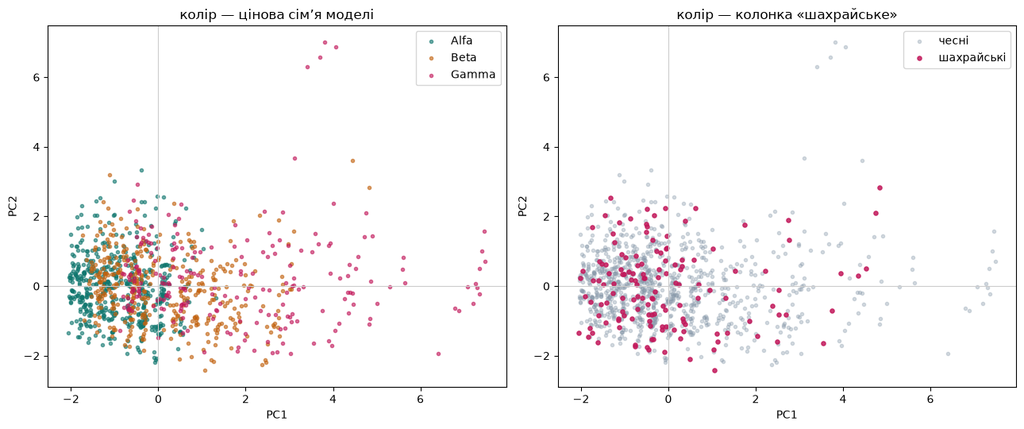

```
медіана PC1 за ціновою сімʼєю:
  Alfa   -1.01
  Beta   -0.32
  Gamma  +1.31

медіана PC1 у шахрайських: -0.38
медіана PC1 у чесних     : -0.43
```

```python
координати = pca.transform(Z)          # 1 100 × 7, нам потрібні перші два стовпці

# цінова сімʼя моделі: Alfa дешеві, Beta середні, Gamma дорогі
сімʼя = оголошення["модель"].str.split().str[0]

фігура, (зліва, справа) = plt.subplots(1, 2, figsize=(13, 5.5))

for назва, колір in [("Alfa", "#0f766e"), ("Beta", "#c2620f"), ("Gamma", "#c2185b")]:
    маска = (сімʼя == назва).to_numpy()
    зліва.scatter(координати[маска, 0], координати[маска, 1],
                  s=9, alpha=0.6, c=колір, label=назва)
зліва.set_title("колір — цінова сімʼя моделі")
зліва.legend()

справа.scatter(координати[таргет == 0, 0], координати[таргет == 0, 1],
               s=9, alpha=0.35, c="#8899aa", label="чесні")
справа.scatter(координати[таргет == 1, 0], координати[таргет == 1, 1],
               s=14, alpha=0.85, c="#c2185b", label="шахрайські")
справа.set_title("колір — колонка «шахрайське»")
справа.legend()

for вісь in (зліва, справа):
    вісь.set_xlabel("PC1")
    вісь.set_ylabel("PC2")
    вісь.axhline(0, lw=0.8, c="#cccccc")
    вісь.axvline(0, lw=0.8, c="#cccccc")

plt.tight_layout()
plt.show()

print("медіана PC1 за ціновою сімʼєю:")
for назва in ["Alfa", "Beta", "Gamma"]:
    маска = (сімʼя == назва).to_numpy()
    print(f"  {назва:6s} {np.median(координати[маска, 0]):+.2f}")
print()
print(f"медіана PC1 у шахрайських: {np.median(координати[таргет == 1, 0]):+.2f}")
print(f"медіана PC1 у чесних     : {np.median(координати[таргет == 0, 0]):+.2f}")
```

Ліворуч структура є: перша компонента впорядкувала оголошення за ціновим класом моделі, хоча колонки «модель» у неї не було. Праворуч структури немає: шахрайські оголошення розсипані так само, як чесні, і медіани в них практично однакові.

Це не поломка. PCA максимізує **розкид**, а не користь для задачі. Найрозкиданіший напрямок у цій таблиці — «дорогий телефон проти дешевого», його метод і повернув. А шахрая видає *відношення* ціни до типової — дія нелінійна, і жодна зважена сума ознак її не відтворює.

## 9 · Без масштабування перша компонента вироджується

Порахуємо PCA ще раз, але на сирій матриці `X`, де ціна виміряна в гривнях, а стан — у балах від 1 до 4.

```python
pca_без_масштабу = PCA().fit(X)

порівняння = pd.DataFrame({
    "стандартне відхилення": X.std(axis=0, ddof=1).round(2),
    "вага в PC1 без масштабу": pca_без_масштабу.components_[0].round(6),
    "вага в PC1 після StandardScaler": pca.components_[0].round(3),
}, index=назви_ознак)
print(порівняння)
print()
print(f"частка PC1 без масштабу        : {pca_без_масштабу.explained_variance_ratio_[0] * 100:.1f} %")
print(f"частка PC1 після StandardScaler: {pca.explained_variance_ratio_[0] * 100:.1f} %")

# сума квадратів ваг усього вектора дорівнює одиниці — подивимось, як вона розподілена
цінові = pca_без_масштабу.components_[0][:3]
решта = pca_без_масштабу.components_[0][3:]
print()
print(f"на три цінові колонки припадає {(цінові ** 2).sum() * 100:.4f} % довжини вектора,")
print(f"на рік, памʼять, стан і вік акаунта разом — {(решта ** 2).sum():.7f}")
```

```
                 стандартне відхилення  вага в PC1 без масштабу  вага в PC1 після StandardScaler
ціна                           8688.98                 0.757664                            0.438
типова_ціна                    5076.98                 0.417038                            0.571
оцінка_каталогу                6149.89                 0.502015                            0.572
рік                               2.31                 0.000090                            0.387
памʼять_гб                      123.78                 0.001648                            0.056
стан_бал                          0.85                 0.000007                            0.018
вік_акаунта                     406.74                -0.001321                           -0.034

частка PC1 без масштабу        : 79.5 %
частка PC1 після StandardScaler: 39.9 %

на три цінові колонки припадає 99.9996 % довжини вектора,
на рік, памʼять, стан і вік акаунта разом — 0.0000045
```

Формально метод відпрацював. Змістовно він побудував складну конструкцію, яка означає «ціна»: решти ознак у першій компоненті просто немає.

## 10 · Витік: PCA, порахований до поділу

PCA не бачить таргета — і саме тому здається, що рахувати його на всіх даних безпечно. Це не так: середні, відхилення й напрямки компонент запамʼятовують тестові рядки, і тест перестає бути незнайомим.

Поміряємо ефект прямо. Метрика проста: яку частку розкиду **тестових** рядків утримують дві компоненти. Робимо це двічі — чесно й з витоком.

```python
# Частка розкиду ТЕСТОВИХ рядків, яку утримують перші компоненти.
# Масштабувальник і PCA вчаться тільки на навчальних рядках — так, як має бути.
def частка_утриманого(навчальні, тестові, скільки_компонент=2):
    свій_масштаб = StandardScaler().fit(навчальні)
    свій_pca = PCA(n_components=скільки_компонент).fit(свій_масштаб.transform(навчальні))
    тест_Z = свій_масштаб.transform(тестові)
    відновлено = свій_pca.transform(тест_Z) @ свій_pca.components_
    return 1 - ((тест_Z - відновлено) ** 2).sum() / (тест_Z ** 2).sum()


# Те саме, але масштабувальник і PCA бачили всі рядки, зокрема тестові.
def частка_утриманого_з_витоком(усі, тестові, скільки_компонент=2):
    спільний_масштаб = StandardScaler().fit(усі)
    спільний_pca = PCA(n_components=скільки_компонент).fit(спільний_масштаб.transform(усі))
    тест_Z = спільний_масштаб.transform(тестові)
    відновлено = спільний_pca.transform(тест_Z) @ спільний_pca.components_
    return 1 - ((тест_Z - відновлено) ** 2).sum() / (тест_Z ** 2).sum()


# один поділ дав би шумне число, тому усереднюємо по тридцяти різних поділах
чесні, з_витоком = [], []
for зерно in range(30):
    навч_індекси, тест_індекси = train_test_split(
        np.arange(len(X)), test_size=0.25, random_state=зерно)
    чесні.append(частка_утриманого(X[навч_індекси], X[тест_індекси]))
    з_витоком.append(частка_утриманого_з_витоком(X, X[тест_індекси]))

print("усі 1 100 оголошень, дві компоненти, середнє по 30 поділах:")
print(f"  чесно     : {np.mean(чесні) * 100:.1f} %")
print(f"  з витоком : {np.mean(з_витоком) * 100:.1f} %")
```

```
усі 1 100 оголошень, дві компоненти, середнє по 30 поділах:
  чесно     : 54.6 %
  з витоком : 56.1 %
```

Півтора відсотка — не катастрофа, і саме тому помилку рідко помічають. Але різниця завжди в один бік, і чим менше даних, тим вона більша. Перевіримо це на маленьких вибірках: 40 оголошень, половина в тест, 200 повторів.

```python
генератор = np.random.default_rng(42)
чесні_виміри, виміри_з_витоком = [], []

for повтор in range(200):
    # беремо випадкові 40 рядків — маленька вибірка, як буває в реальних задачах
    вибірка = X[генератор.choice(len(X), size=40, replace=False)]
    навч, тест = train_test_split(np.arange(40), test_size=0.5, random_state=повтор)
    чесні_виміри.append(частка_утриманого(вибірка[навч], вибірка[тест]))
    виміри_з_витоком.append(частка_утриманого_з_витоком(вибірка, вибірка[тест]))

print("40 оголошень, 200 повторів, дві компоненти:")
print(f"  чесно     : {np.mean(чесні_виміри) * 100:.1f} %")
print(f"  з витоком : {np.mean(виміри_з_витоком) * 100:.1f} %")
print()
розрив = (np.mean(виміри_з_витоком) - np.mean(чесні_виміри)) * 100
print(f"Розрив — {розрив:.1f} відсоткового пункту, і він вигаданий:")
print("PCA припасувався саме до тих рядків, на яких його потім перевіряють.")
```

```
40 оголошень, 200 повторів, дві компоненти:
  чесно     : 53.4 %
  з витоком : 62.8 %

Розрив — 9.4 відсоткового пункту, і він вигаданий:
PCA припасувався саме до тих рядків, на яких його потім перевіряють.
```

Правильно так: `StandardScaler` і `PCA` кладуться в `Pipeline` разом із моделлю (тема 09). Тоді на кожному згині крос-валідації вони перераховуються заново й тільки на навчальній частині згину.

## Завдання

### 🟢 Рівень 1

Побудуй **графік накопиченої поясненої дисперсії**: по горизонталі кількість компонент від 1 до 7, по вертикалі накопичений відсоток, горизонтальна пунктирна лінія на рівні 90 %. Підпиши точку, у якій крива перетинає поріг.

### 🟡 Рівень 2

Викинь із таблиці колонку `оцінка_каталогу` — ту саму, що майже дублює `типова_ціна`. Порахуй PCA на шести ознаках, що лишились, і порівняй із семи: скільки компонент тепер треба для 90 % і що сталося з останнім власним числом. Поясни результат одним реченням.

### 🔴 Рівень 3

Заміни три цінові колонки їхніми **логарифмами** (`np.log`) і повтори весь розділ 8. Подивись на PC1–PC2 знову: чи стало видно шахрайські оголошення? Знайди компоненту, у якій ваги `лог_ціна` та `лог_типова_ціна` мають різні знаки — і поясни, чому саме вона й є «відхилення ціни від типової» з теми 10, та який у неї внесок у загальний розкид.